# Информация как ценность. Понятие об информационных угрозах

Доклад

Филипьева К.Д.

Российский университет дружбы народов, Москва, Россия

29 марта 2025

# Информация

## Докладчик

- Филипьева Ксения Дмитриевна
- Студент
- Российский университет дружбы народов
- 1132230795@pfur.ru

## Введение

Цель данной работы — рассмотреть информацию как ценность, а также дать представление об информационных угрозах и способах их предотвращения.

## Информация: что это такое и почему она имеет ценность?

Информация — это знание, передаваемое с помощью символов, сигналов и других знаков.

### Факторы ценности информации

- Актуальность
- Достоверность
- Полнота
- Уникальность
- Доступность

## Факторы ценности информации

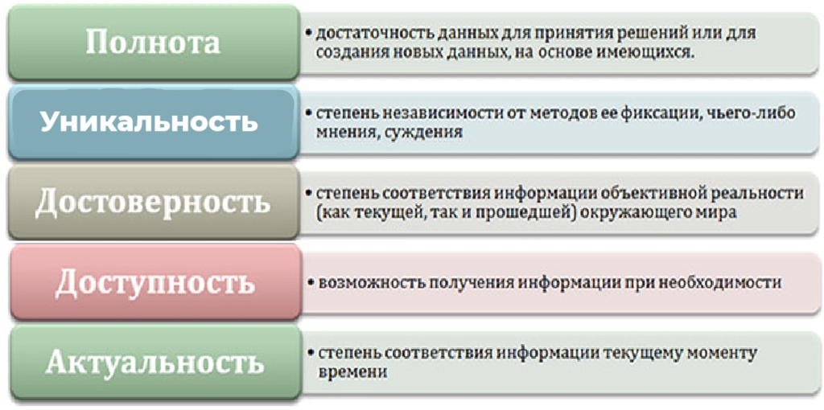

Факторы ценности информации

## Информационные угрозы: понятие и типология

Информационные угрозы — это потенциальные или реальные действия, которые могут привести к утрате, искажению, блокированию или несанкционированному распространению информации.

### Источники угроз:

- Внешние злоумышленники
- Внутренние лица
- Случайные обстоятельства
- Ошибки в системе управления

## Классификация угроз

| Тип угрозы | Примеры | Возможные последствия |
| --- | --- | --- |
| Технические | Вирусы, трояны, DDOS-атаки | Потеря данных, сбои в системах |
| Человеческий фактор | Ошибки операторов, халатность | Утечка данных, удаление файлов |
| Социально-психологические | Фишинг, вишинг, соц. инженерия | Доступ к логинам и паролям |
| Организационные | Недостатки в политике безопасности | Необоснованный доступ |
| Стихийные бедствия | Пожары, наводнения, отключение света | Физическое разрушение оборудования |

## Современные информационные угрозы

### Кибератаки

Наиболее опасные угрозы — это атаки, направленные на взлом информационных систем.

### Манипуляция сознанием через соцсети

Информация используется как оружие — для управления общественным мнением.

### Утечки данных

Часто происходят из-за человеческого фактора.

## Методы защиты информации

- Криптографическая защита
- Аутентификация и контроль доступа
- Антивирусное ПО и межсетевые экраны
- Резервное копирование
- Обучение персонала

## Схема комплексной системы информационной безопасности

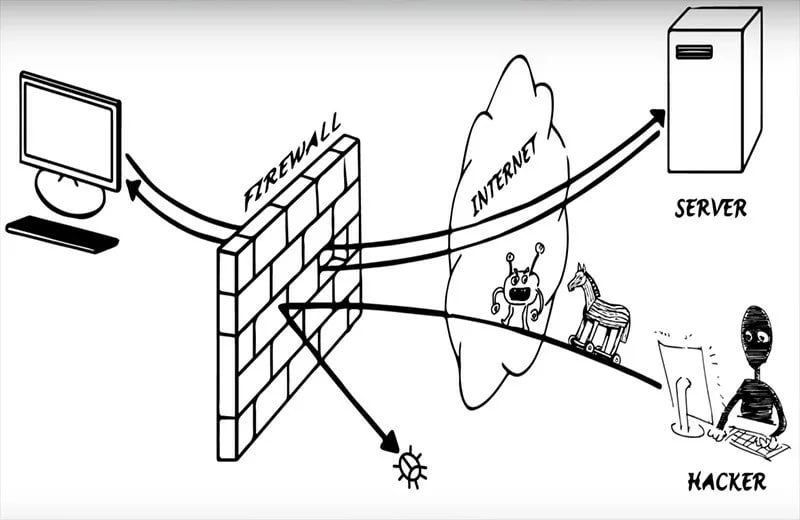

## Заключение

### Информация — стратегический ресурс

- В современном мире информация имеет высокую ценность.

### Информационные угрозы — многогранны

- Угрозы бывают техническими, организационными и социальными.

### Безопасность информации — общая ответственность

- Требуется комплексный подход.